# Dateninspektion

# Dateninspektion

```r
#Installation des Pakets
# install.packages("PASWR") # die Installatien muss man nur einmal machen
#Laden der library:
library(PASWR) #damit stehen Ihnen nun sämtliche Funktionen und Datensätze dieser Bibliothek zur Verfügung
library(tidyverse) #nützliches Packet zur Tabellenbearbeitung. Lädt ggplot2, eine sehr mächtige Graphikbibliothek
library(ggpubr) #eine Bibliothek für publikationsreife Graphen
```

## 1. Datensatz betrachten

Meist beginnt die Datenanalyse damit, dass man irgendwoher Daten bekommt und je nach Fragestellung bestimmte Analysen durchführt. So stellt es sich die Data Scientist zumindest vor. In Wahrheit verbringt sie jedoch den Großteil ihrer Arbeitszeit damit, die Daten zusammenzutragen (z.B. durch Webscraping oder Datenbankabfragen) und sie zu putzen. Nur zu oft enthält der Datensatz fehlende oder unplausible Werte. Auch die Verteilung der Daten spielt eine große Rolle, welche statistischen Verfahren anwendbar sind. Eine Datenanalyse sollte man folglich niemals blind durchführen, sondern sich permanent vergewissern, dass man nicht in die Falle “garbage in - garbage out” fällt.

Das Erstellen des Datensatzes geht über den Einstiegskurs hinaus. Stattdessen bedienen wir uns im Kurs Datensätze, die mit der Installation von R zur Verfügung stehen oder im PASWR Paket enthalten sind. Diese kann man direkt aufrufen. Der Datensatz ist unter dem Namen “airquality” vorhanden. Der Befehlt head() zeigt die ersten 6 Zeilen des Dataframes.

```r
head(airquality)
```

|  | Ozone | Solar.R | Wind | Temp | Month | Day |
| --- | --- | --- | --- | --- | --- | --- |
| 1 | 41 | 190 | 7.4 | 67 | 5 | 1 |
| 2 | 36 | 118 | 8.0 | 72 | 5 | 2 |
| 3 | 12 | 149 | 12.6 | 74 | 5 | 3 |
| 4 | 18 | 313 | 11.5 | 62 | 5 | 4 |
| 5 | NA | NA | 14.3 | 56 | 5 | 5 |
| 6 | 28 | NA | 14.9 | 66 | 5 | 6 |

Wir erkennen sofort, dass der Datensatz fehlende Werte enthält. Dies kann man systematisch überprüfen:

```r
summary(airquality)
```

```
##      Ozone           Solar.R           Wind             Temp
##  Min.   :  1.00   Min.   :  7.0   Min.   : 1.700   Min.   :56.00
##  1st Qu.: 18.00   1st Qu.:115.8   1st Qu.: 7.400   1st Qu.:72.00
##  Median : 31.50   Median :205.0   Median : 9.700   Median :79.00
##  Mean   : 42.13   Mean   :185.9   Mean   : 9.958   Mean   :77.88
##  3rd Qu.: 63.25   3rd Qu.:258.8   3rd Qu.:11.500   3rd Qu.:85.00
##  Max.   :168.00   Max.   :334.0   Max.   :20.700   Max.   :97.00
##  NA's   :37       NA's   :7
##      Month            Day
##  Min.   :5.000   Min.   : 1.0
##  1st Qu.:6.000   1st Qu.: 8.0
##  Median :7.000   Median :16.0
##  Mean   :6.993   Mean   :15.8
##  3rd Qu.:8.000   3rd Qu.:23.0
##  Max.   :9.000   Max.   :31.0
##
```

Ein anderer Datensatz (zu Titanik) demonstriert ein weiteres Problem, nämlich Dubletten:

```r
head(titanic3)
```

|  | pclass | survived | name | sex | age | sibsp | parch | ticket | fare | cabin | embarked | boat | body | home.dest |
| --- | --- | --- | --- | --- | --- | --- | --- | --- | --- | --- | --- | --- | --- | --- |
| 1 | 1st | 1 | Allen, Miss. Elisabeth Walton | female | 29.0000 | 0 | 0 | 24160 | 211.3375 | B5 | Southampton | 2 | NA | St Louis, MO |
| 2 | 1st | 1 | Allison, Master. Hudson Trevor | male | 0.9167 | 1 | 2 | 113781 | 151.5500 | C22 C26 | Southampton | 11 | NA | Montreal, PQ / Chesterville, ON |
| 3 | 1st | 0 | Allison, Miss. Helen Loraine | female | 2.0000 | 1 | 2 | 113781 | 151.5500 | C22 C26 | Southampton |  | NA | Montreal, PQ / Chesterville, ON |
| 4 | 1st | 0 | Allison, Mr. Hudson Joshua Crei | male | 30.0000 | 1 | 2 | 113781 | 151.5500 | C22 C26 | Southampton |  | 135 | Montreal, PQ / Chesterville, ON |
| 5 | 1st | 0 | Allison, Mrs. Hudson J C (Bessi | female | 25.0000 | 1 | 2 | 113781 | 151.5500 | C22 C26 | Southampton |  | NA | Montreal, PQ / Chesterville, ON |
| 6 | 1st | 1 | Anderson, Mr. Harry | male | 48.0000 | 0 | 0 | 19952 | 26.5500 | E12 | Southampton | 3 | NA | New York, NY |

```r
# der Datensatz hat ff Dimensionen
dim(titanic3)
```

```
## [1] 1309   14
```

```r
# Wieviele Dubletten sind vorhanden?
sum(duplicated(titanic3$name))
```

```
## [1] 2
```

```r
# wievele verschiedene Werte gibt es? Entweder so:
length(unique(titanic3$name))
```

```
## [1] 1307
```

```r
# oder so:
titanic3 %>% distinct(name)
```

| name |
| --- |
| Allen, Miss. Elisabeth Walton |
| Allison, Master. Hudson Trevor |
| Allison, Miss. Helen Loraine |
| Allison, Mr. Hudson Joshua Crei |
| Allison, Mrs. Hudson J C (Bessi |
| Anderson, Mr. Harry |
| Andrews, Miss. Kornelia Theodos |
| Andrews, Mr. Thomas Jr |
| Appleton, Mrs. Edward Dale (Cha |
| Artagaveytia, Mr. Ramon |

[output cut: 1297 more lines]

```r
# Suche nach Dubletten
titanic3 %>%
  group_by(name) %>%
  tally() %>%
  arrange(desc(n))
```

| name | n |
| --- | --- |
| Connolly, Miss. Kate | 2 |
| Kelly, Mr. James | 2 |
| Abbing, Mr. Anthony | 1 |
| Abbott, Master. Eugene Joseph | 1 |
| Abbott, Mr. Rossmore Edward | 1 |
| Abbott, Mrs. Stanton (Rosa Hunt | 1 |
| Abelseth, Miss. Karen Marie | 1 |
| Abelseth, Mr. Olaus Jorgensen | 1 |
| Abelson, Mr. Samuel | 1 |
| Abelson, Mrs. Samuel (Hannah Wi | 1 |

[output cut: 1297 more lines]

Wir sehen, dass Kate Connolly und James Kelly zweimal geführt werden. Ob dies Namensvettern sind oder echte Duplikate und damit bearbeitet werden müssen, muss detailliert überprüft werden:

```r
titanic3 %>%
  filter(name=="Connolly, Miss. Kate" | name=="Kelly, Mr. James")
```

| pclass | survived | name | sex | age | sibsp | parch | ticket | fare | cabin | embarked | boat | body | home.dest |
| --- | --- | --- | --- | --- | --- | --- | --- | --- | --- | --- | --- | --- | --- |
| 3rd | 1 | Connolly, Miss. Kate | female | 22.0 | 0 | 0 | 370373 | 7.7500 |  | Queenstown | 13 | NA | Ireland |
| 3rd | 0 | Connolly, Miss. Kate | female | 30.0 | 0 | 0 | 330972 | 7.6292 |  | Queenstown |  | NA | Ireland |
| 3rd | 0 | Kelly, Mr. James | male | 34.5 | 0 | 0 | 330911 | 7.8292 |  | Queenstown |  | 70 |  |
| 3rd | 0 | Kelly, Mr. James | male | 44.0 | 0 | 0 | 363592 | 8.0500 |  | Southampton |  | NA |  |

Offenbar sind es echte Namensvettern und können bleiben. Allerdings wissen wir jetzt auch, dass wir in diesem Datensatz den Namen NICHT als unique identifier benutzen können und stattdessen den Passagieren eine andere ID vergeben müssten.

## 2. Daten putzen

### 2.1 Dubletten entfernen

Wenn wir auf Nummer sicher gehen wollen würden, würden wir dennoch die beiden duplizierten Passagiere entfernen:

```r
titanik_df <- titanic3[unique(titanic3$name), ]
# prüfe, dass die Dimension sich geändert hat
dim(titanik_df)
```

```
## [1] 1307   14
```

### 2.2 Missspezifikation des Datentyps

Sowohl der Monat als auch der Tag im airquality Datensatz sind als Integer angegeben. Dies könnte später zu Problemen führen, z.B. bei der Darstellung. Deswegen benennen wir den Inhalt der Spalte um.

```r
# z.B mit case_when aus dplyr (das ist eine generelle Möglichkeit)
airquality <- airquality %>%
    mutate(
    Monthname = case_when(
          Month %in% 1 ~ "Jan",
          Month %in% 2 ~ "Feb",
          Month %in% 3 ~ "Mar",
          Month %in% 4 ~ "Apr",
          Month %in% 5 ~ "May",
          Month %in% 6 ~ "Jun",
          Month %in% 7 ~ "Jul",
          Month %in% 8 ~ "Aug",
          Month %in% 9 ~ "Sep",
          Month %in% 10 ~ "Oct",
          Month %in% 11 ~ "Nov",
          Month %in% 12 ~ "Dec"
    )
  )

# Bei Monatsnamen geht es aber einfacher:
airquality$Monthname <- month.abb[airquality$Month]
```

### 2.3 Fehlende Werte

Wir haben oben bereits gesehen, dass airquality einige fehlende Werte hat. Zur Erinnerung:

```r
sum(is.na(airquality))
```

```
## [1] 44
```

(44 Werte sind NA)

Es gibt verschiedene Ansätze, mit fehlenden Werten umzugehen. Zu unterscheiden sind Fälle, 1) wo fehlende Werte auf Probleme in der Datenerhebung deuten und 2) sog. „informed missingness“, wo die Abwesenheit eines Werts eine Aussage tragen könnte (z.B. fehlende Antworten bei Umfragen) Behebung von 1):

- Löschen des Datensatzes
- Globale Konstante („n.d“)
- Lageparameter (Mittelwert, Median)
- Wahrscheinlicher Wert

Welche Methode ist wann zu wählen? Tipp: schauen Sie sich die Verteilung an.

```r
#Wieviele NA-Problemfälle gibt es?
apply(airquality, 2,function(x) sum(is.na(x)))
```

```
##     Ozone   Solar.R      Wind      Temp     Month       Day Monthname
##        37         7         0         0         0         0         0
```

Wir brauchen uns nur die Spalten Ozone und Solar.R genauer anzuschauen.

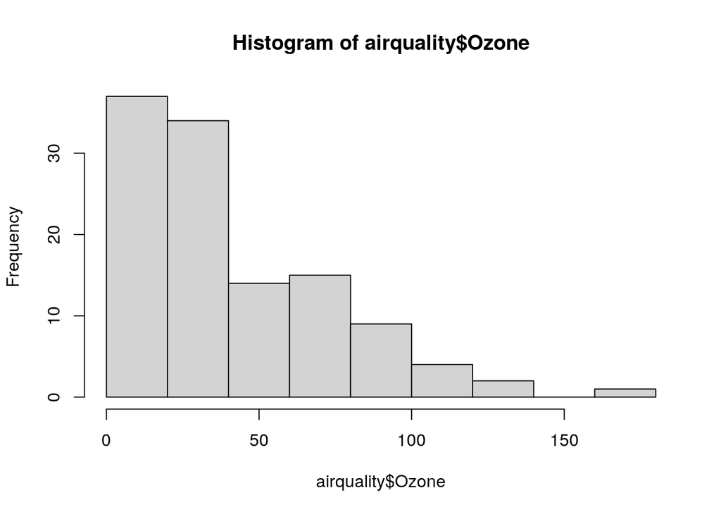

```r
hist(airquality$Ozone)
```

Eine andere weise, die Verteilung zu betrachten, ist der DIchteplot:

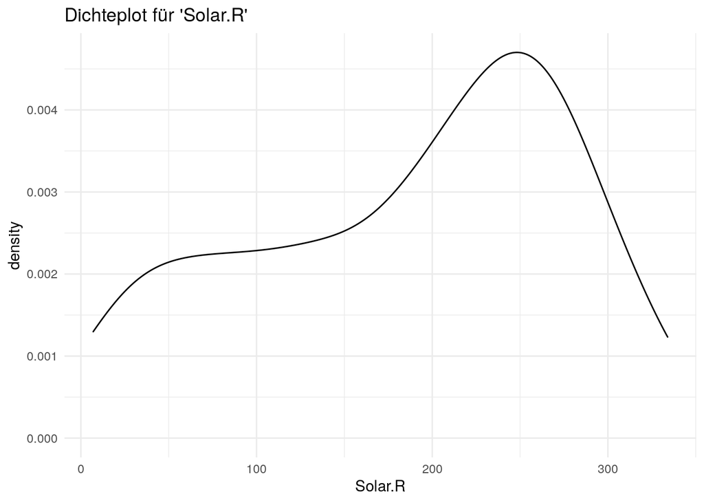

```r
ggplot(airquality, aes(x = Solar.R)) +
  geom_density() +
  ggtitle("Dichteplot für 'Solar.R'") +
  theme_minimal()
```

In beiden Fällen sind die Daten nicht normalverteilt. Folglich sind wir auf der sichereren Seite, wenn wir fehlende Werte durch den Median ersetzen:

```r
#Ersetze NA's
airquality$Ozone[is.na(airquality$Ozone)] <- median(airquality$Ozone, na.rm=T)
airquality$Solar.R[is.na(airquality$Solar.R)] <- median(airquality$Solar.R, na.rm=T)
```

Nebenbemerkung 1: es gibt sog. “informed missingness” Fälle, in denen die Abwesenheit der Daten nicht unbedingt für schlechte Datenqualität spricht, sondern eine Aussage trägt, z.B. wenn bei Umfragen bestimmte Fragen nicht beantwortet werden.

Nebenbemerkung 2: es gibt inzwischen etwas fancigere Methoden, um NA’s zu füllen, z.B. durch Extrapolation durch maschinelle Lernalgorithmen (s. z.B. randomForest::rfImpute()).

Eine schöne Einführung samt weiterführenden Methoden ist z.B. bei Garcıa-Laencina et al., zu finden [Pattern classification with missing data: a review](https://www.semanticscholar.org/paper/Pattern-classification-with-missing-data%3A-a-review-Garc%C3%ADa-Laencina-Sancho-G%C3%B3mez/3f631c73b429fd2e59ab0b2a80a12a42d6fd00a8).

```r
#so sieht jetzt der Datensatz aus:
str(airquality)
```

```
## 'data.frame':    153 obs. of  7 variables:
##  $ Ozone    : num  41 36 12 18 31.5 28 23 19 8 31.5 ...
##  $ Solar.R  : num  190 118 149 313 205 205 299 99 19 194 ...
##  $ Wind     : num  7.4 8 12.6 11.5 14.3 14.9 8.6 13.8 20.1 8.6 ...
##  $ Temp     : int  67 72 74 62 56 66 65 59 61 69 ...
##  $ Month    : int  5 5 5 5 5 5 5 5 5 5 ...
##  $ Day      : int  1 2 3 4 5 6 7 8 9 10 ...
##  $ Monthname: chr  "May" "May" "May" "May" ...
```

```r
summary(airquality)
```

```
##      Ozone           Solar.R           Wind             Temp
##  Min.   :  1.00   Min.   :  7.0   Min.   : 1.700   Min.   :56.00
##  1st Qu.: 21.00   1st Qu.:120.0   1st Qu.: 7.400   1st Qu.:72.00
##  Median : 31.50   Median :205.0   Median : 9.700   Median :79.00
##  Mean   : 39.56   Mean   :186.8   Mean   : 9.958   Mean   :77.88
##  3rd Qu.: 46.00   3rd Qu.:256.0   3rd Qu.:11.500   3rd Qu.:85.00
##  Max.   :168.00   Max.   :334.0   Max.   :20.700   Max.   :97.00
##      Month            Day        Monthname
##  Min.   :5.000   Min.   : 1.0   Length:153
##  1st Qu.:6.000   1st Qu.: 8.0   Class :character
##  Median :7.000   Median :16.0   Mode  :character
##  Mean   :6.993   Mean   :15.8
##  3rd Qu.:8.000   3rd Qu.:23.0
##  Max.   :9.000   Max.   :31.0
```

### 2.4 Ausreißer

Ausreißer können ihre gesamte Analyse zunichte machen, weshalb Sie die Daten daraufhin unbedingt prüfen müssen. Eine Ausreisßerdefinition besagt, dass Ausreißer Punkte sind, die unter Q(1/4)−3/2 IQR oder über Q(3/4)+3/2 IQR liegen. Haben Sie solche Daten im Datensatz, können Sie die Ausreißer unterschiedlich behandeln:

- Kappen
- Löschen
- Imputieren
- Binnen + Glätten
- Glätten von Zeitreihen

Wir berechnen zunächst für eine Spalte, ob wir Ausreißerpunkte haben:

```r
quantile(airquality$Ozone)
```

```
##    0%   25%   50%   75%  100%
##   1.0  21.0  31.5  46.0 168.0
```

Diese können wir uns rausgeben lassen:

```r
lower_bound <- quantile(airquality$Ozone)[2] - 3/2 * IQR(airquality$Ozone)
upper_bound <- quantile(airquality$Ozone)[4] + 3/2 * IQR(airquality$Ozone)
airquality$Ozone[which(airquality$Ozone < lower_bound | airquality$Ozone > upper_bound)]
```

```
##  [1] 115 135  97  97  85 108 122  89 110 168 118  84  85  96  91
```

Wir sollten nur noch bedenken, dass wir eine mögliche saisonale Komponente im Datensatz haben, weshalb es sinnvoll sein könnte, die Ausreißer pro Monat zu betrachten.

```r
for (mo in unique(airquality$Monthname)){
  print(mo)
  lower_bound <- quantile(airquality$Ozone[airquality$Monthname==mo])[2] - 3/2 * IQR(airquality$Ozone[airquality$Monthname==mo])
  upper_bound <- quantile(airquality$Ozone[airquality$Monthname==mo])[4] + 3/2 * IQR(airquality$Ozone[airquality$Monthname==mo])
  print(airquality$Ozone[airquality$Monthname==mo][which(airquality$Ozone[airquality$Monthname==mo] < lower_bound | airquality$Ozone[airquality$Monthname==mo] > upper_bound)])
}
```

```
## [1] "May"
## [1] 115
## [1] "Jun"
## [1] 29 71 39 23 21 37 20 12 13
## [1] "Jul"
## numeric(0)
## [1] "Aug"
## [1] 168
## [1] "Sep"
## [1] 96 78 73 91
```

Diese ersetzen wir nun mit dem Mittelwert des jeweiligen Monats:

```r
for (mo in unique(airquality$Monthname)){
  print(mo)
  lower_bound <- quantile(airquality$Ozone[airquality$Monthname==mo])[2] - 3/2 * IQR(airquality$Ozone[airquality$Monthname==mo])
  upper_bound <- quantile(airquality$Ozone[airquality$Monthname==mo])[4] + 3/2 * IQR(airquality$Ozone[airquality$Monthname==mo])
  airquality$Ozone[airquality$Monthname==mo][which(airquality$Ozone[airquality$Monthname==mo] < lower_bound | airquality$Ozone[airquality$Monthname==mo] > upper_bound)] <- mean(airquality$Ozone[airquality$Monthname==mo])
}
```

```
## [1] "May"
## [1] "Jun"
## [1] "Jul"
## [1] "Aug"
## [1] "Sep"
```

## 3. Daten plotten

Viele der Schritte, die wir bisher unternommen haben, lassen sich durch entsprechende Grafiken vereinfachen bzw. verifizieren. Obwohl base R bereits Befehle für Grafiken enthält, hat sich mit der ggplot2 Bibliothek ein quasi-Standard etabliert. Eine Kurzanleitung finden sie [hier](https://www.maths.usyd.edu.au/u/UG/SM/STAT3022/r/current/Misc/data-visualization-2.1.pdf) (sollte der Link nicht funktionieren, suchen Sie nach ggplot cheat sheet)

Dies ist ein Beispiel für ein Streudiagramm:

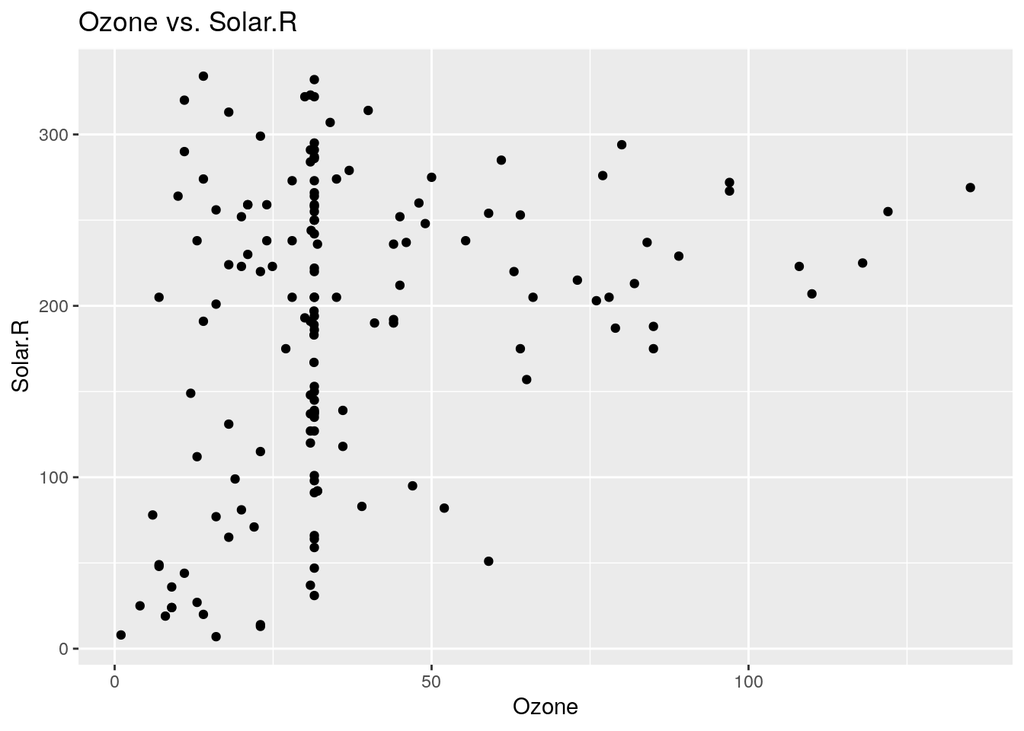

```r
plot <- ggplot(data = airquality, aes(x=Ozone, y=Solar.R)) +
  geom_point() +
  ggtitle("Ozone vs. Solar.R")
plot
```

Man kann auch mehrere Parameter gleichzeitig plotten, z.B. so:

```r
# install.packages("GGally")
library(GGally)
```

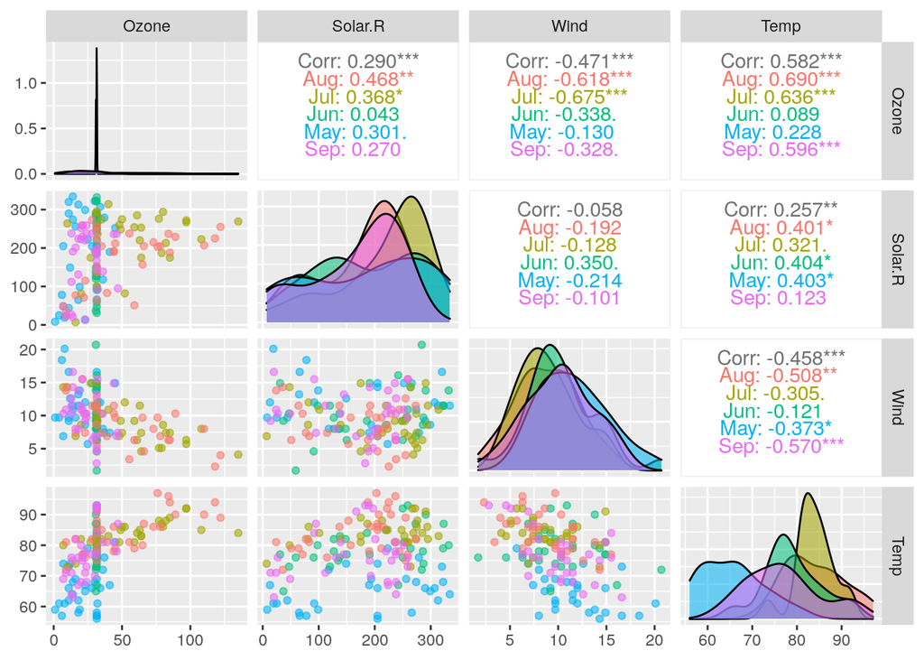

```r
ggpairs(airquality,                 # Data frame
        columns = 1:4,        # Auswahl der Spalten
        aes(color = Monthname,  # Color nach Monat
            alpha = 0.5))     # Transparenz
```

Sehr hilfreich, insbesondere für die Bestimmung von Ausreißern, sind Boxplots:

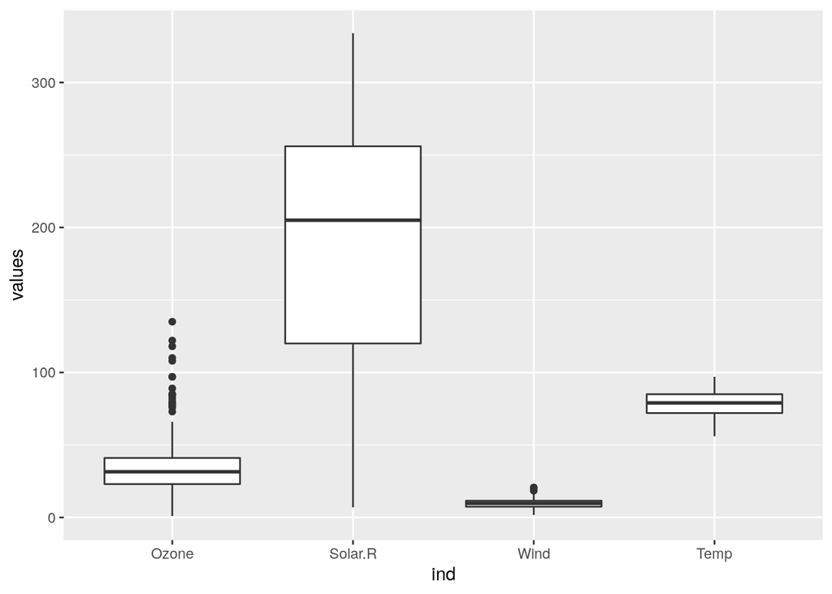

```r
airquality %>%
  select(c(1:4)) %>%
  stack(.) %>%
    ggplot(., aes(x = ind, y = values)) +
      geom_boxplot()
```

Oder, etwas genauer, pro Monat:

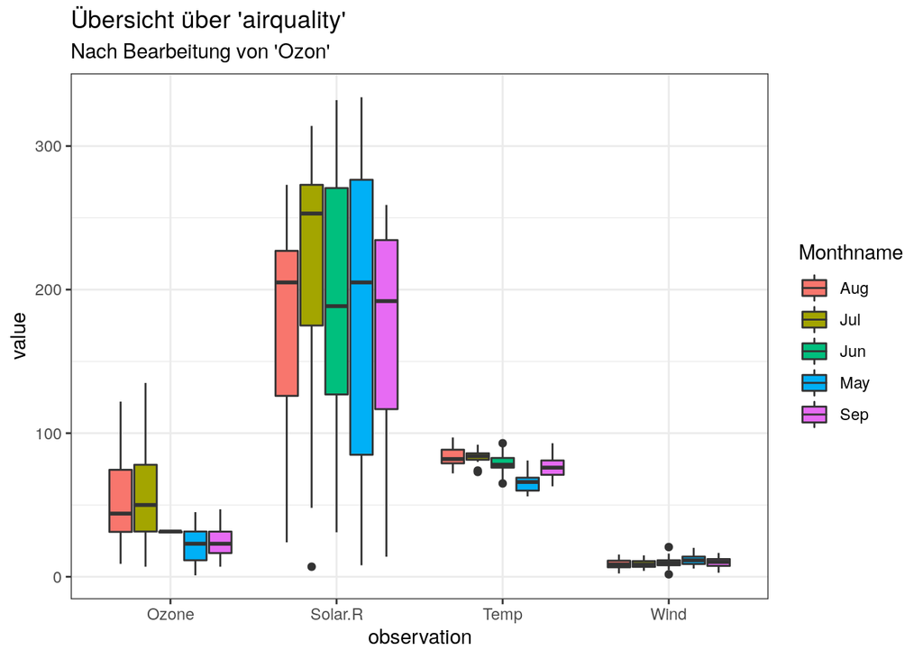

```r
airquality %>%
  select(Ozone, Solar.R, Wind, Temp, Monthname) %>%
  pivot_longer(c(Ozone, Solar.R, Wind, Temp), names_to = "observation", values_to = "value") %>% # wir brauchen die Daten im long-Format
    ggplot(., aes(x = observation, y = value)) + # definiere, was geplottet werden soll
      geom_boxplot(aes(fill=Monthname)) + # definiere Plottyp
      theme_bw() + # Aufhübschen des Plots
      ggtitle("Übersicht über 'airquality'", subtitle = "Nach Bearbeitung von 'Ozon'")
```

Da es sich bei airquality um einen Datensatz mit einer zeitlichen Komponente handelt, können wir hier auch einen Time course plot zeichnen. Dafür brauchen wir eine Spalte mit Datumsangaben:

```r
airquality$date <- as.Date(paste0(airquality$Day, "-" ,airquality$Month), "%d-%m")
```

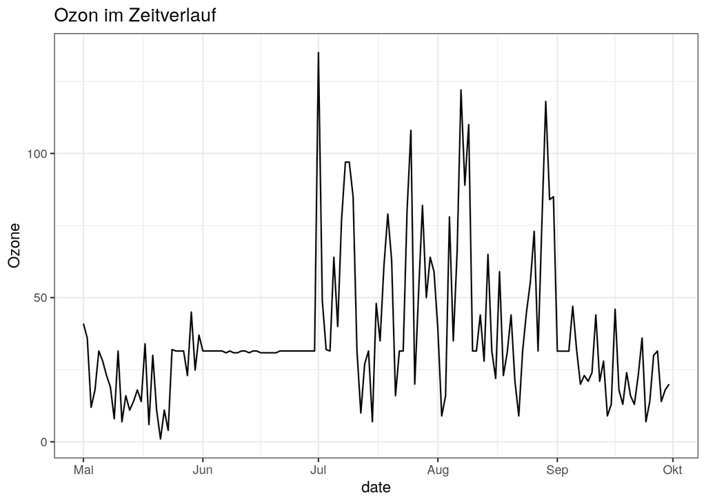

```r
ggplot(airquality, aes(x = date, y = Ozone)) +
  geom_line() +
  theme_bw() + # Aufhübschen des Plots
  ggtitle("Ozon im Zeitverlauf")
```

## Aufgaben

1. Schauen Sie sich den Datensatz ‘airquality’ noch einmal an. Gibt es in anderen Parametern als ‘Ozone’ noch Ausreißer oder fehlende Werte? Falls ja, beheben sie diese. Vergewissern sie sich, wie die Daten jetzt aussehen, indem sie sie im Zeitverlauf und im Boxplot plotten.
2. Laden Sie sich das Cheatsheet zu ggplot2 herunter (s. google). Spielen sie mit den verschiedenen Einstellungen. Wie kann man den Plot noch ansprechende machen?
3. Probieren Sie statt des Boxplots den Violinplot aus (geom_violin()). Eine andere schöne Datenvisualisierung ist der Raincloud plot. Recherchieren Sie, wie sie ihn mit ggplot erstellen können.